# Covid_Code_SNB_group_Hapcentred

2023-04-28

# Questions to Dirk and Rui 28.04.2023:

1. shall we go into more detail about each analysis?
2. Should we include means and some descriptive statistics, and was it helpful to include inferential statistics?
3. How to get one “average” regression line into the penultimate plot?

# To do for pitch 12/05/2023:

- create two slide presentation similar to the final one
- simplify the data pitch, particularly for the short pitch: data sources and processing (need to imagine to present it to someone who does not know what a data frame is; focus on the framework; don’t mention regression)
- lancet study came too early, gave the impression that this is a clincial project // consider cutting it // what is the causal link between MH and Happiness??? / make the link between research on clinical sample and general population more clear!
- spend more time on the measures and how they can mean happiness –> how do these impact happiness
- results much clearer: what are the results, 3 limitations and 3 implications –> clear “Take-Home-Message”

–> Clearer rationale and simpler research question: focus on just one or two things and really specifcy why this is important & how you rationalise it

- strictly two slides, the second slide should reflect the main finding!
1. Rationale for regional differences -> Plan: compare Western Europe to Sars-Cov-1 countries - justify “preparedness”
2. Average of 15-19 –> standardise, then compare change levels
3. compare across years –> changes over time pre-, peri- and post-pandemic

read in the happiness data from 2020 to see if there is an effect of covid-deaths on happiness

libraries and packages to load and step by step guide

1. read Oxford stringency alltimes data xls file
2. filter for total country to get rid of states
3. delete unnecessary columns
4. df by year
5. transpose by year
6. calculate mean stringency by year
7. combine to one table incl country_code
8. delete all countries with stringency NA
9. rename
10. transpose
11. visualizing stringency per country 2020-2022
12. load happiness scores
13. combine happiness with Stringency, centre happiness
14. visualizing Stringency vs Happiness per year 2020-2022
15. visualizing Happiness per country and per region over time 2019-2022 transpose first
16. visualizing Stringency per country and region over time 2020-2022 transpose first

# Covid Death Data

21. load covid data, then unselect unnecessary columns

Source: (Edouard Mathieu, Hannah Ritchie, Lucas Rodés-Guirao, Cameron Appel, Charlie Giattino, Joe Hasell, Bobbie Macdonald, Saloni Dattani, Diana Beltekian, Esteban Ortiz-Ospina and Max Roser (2020) - “Coronavirus Pandemic (COVID-19)”. Published online at OurWorldInData.org. Retrieved from: ‘https://ourworldindata.org/coronavirus’ [Online Resource] )

22. Group data, compute date variable, create numeric days variable
23. create total covid data for each year
24. create covid data frame for cases and deaths for each year, then view result
25. combine tables together to create total data_frame
26. mutate Differences between 2021 and 2020 & 2022 and 2021
27. set differences for 2019 and 2020 to 0
28. view col names, then install packages to relocate and reorder column names for pivoting
29. pivot longer to get years in each row (one column), then pivot wider to get separate columns for deaths and cases
30. rename colnames to fit colnames in happiness and stringency data frames
31. create total data frame with cases, deaths, stringency and happiness
32. remove duplicate column
33. rename other duplicate appropriately and view data frame
34. remove NAs from Dataset for countries without a happiness score and remove 2019 as it is no longer needed
35. create new data frames to keep “raw” data
36. test relationship between Stringency and Happiness + create plots
37. test happiness vs. death differences and create plots

```r
hap_death <- lm(Happiness ~ DeathsPerMillion, data = total_data)
summary(hap_death)
```

```
##
## Call:
## lm(formula = Happiness ~ DeathsPerMillion, data = total_data)
##
## Residuals:
##      Min       1Q   Median       3Q      Max
## -2.27596 -0.23399 -0.00662  0.33638  1.26028
##
## Coefficients:
##                   Estimate Std. Error t value Pr(>|t|)
## (Intercept)      5.443e-02  3.125e-02   1.742   0.0825 .
## DeathsPerMillion 8.989e-05  4.008e-05   2.243   0.0256 *
## ---
## Signif. codes:  0 '***' 0.001 '**' 0.01 '*' 0.05 '.' 0.1 ' ' 1
##
## Residual standard error: 0.445 on 334 degrees of freedom
## Multiple R-squared:  0.01483,    Adjusted R-squared:  0.01188
## F-statistic: 5.029 on 1 and 334 DF,  p-value: 0.02558
```

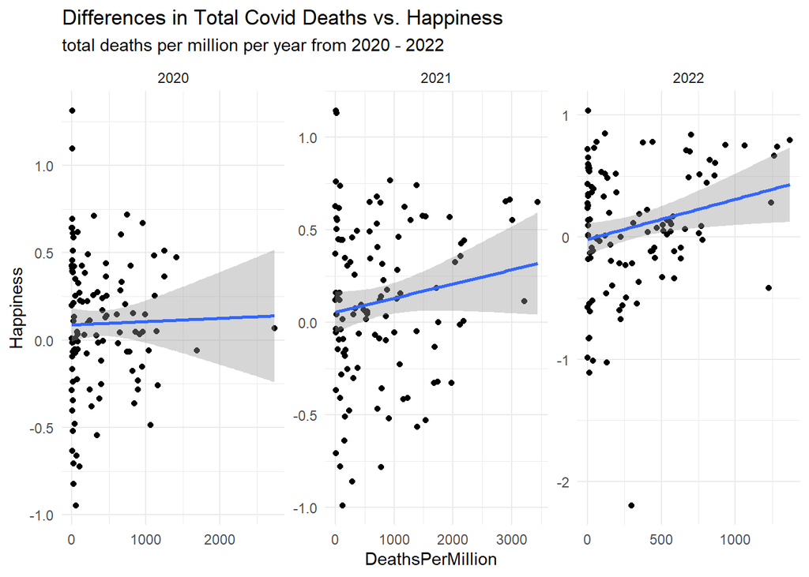

```r
happiness_by_deaths <- total_data %>%
  ggplot(aes(x = DeathsPerMillion, y = Happiness))+ #, col=deathsdiff)) +
  geom_point() + #(aes(size=deathsdiff)) +
  theme_minimal() +
  scale_colour_gradientn(colors=rainbow(7)) +
  labs(title="Differences in Total Covid Deaths vs. Happiness", subtitle="total deaths per million per year from 2020 - 2022") +
  theme(legend.position = "bottom", legend.text = element_text(size = 5)) +
  facet_wrap(~year, scale = "free") + stat_smooth(method = 'lm')
happiness_by_deaths
```

38. test happiness vs. stringency and deathsdiff, create plots

```
##
## Call:
## lm(formula = Happiness ~ Stringency * DeathsPerMillion, data = total_data)
##
## Residuals:
##      Min       1Q   Median       3Q      Max
## -2.29954 -0.25764 -0.00239  0.30034  1.27663
##
## Coefficients:
##                               Estimate Std. Error t value Pr(>|t|)
## (Intercept)                  1.584e-02  8.654e-02   0.183  0.85485
## Stringency                   5.791e-04  1.862e-03   0.311  0.75601
## DeathsPerMillion             4.437e-04  1.517e-04   2.924  0.00369 **
## Stringency:DeathsPerMillion -6.783e-06  2.909e-06  -2.331  0.02034 *
## ---
## Signif. codes:  0 '***' 0.001 '**' 0.01 '*' 0.05 '.' 0.1 ' ' 1
##
## Residual standard error: 0.4411 on 332 degrees of freedom
## Multiple R-squared:  0.038,  Adjusted R-squared:  0.0293
## F-statistic: 4.371 on 3 and 332 DF,  p-value: 0.004904
```

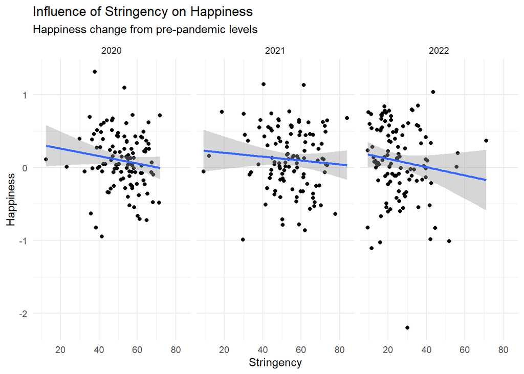

39. plot cases vs. happiness and test it
40. Test Casediff and stringency and plot
41. for now, no furhter analysis on potential moderation effects
42. create subsets per year, then run regression of Stringency on Happiness per year to assess yearly differences in relationship between Stringency and Happiness
43. plot models per year
44. plot
45. add continent